# INFO 201/PS5

Moyi Li

2023-02-19

## 1. Load and Check data

There are 13055 rows and 25 columns! The small sample of data looks great!

```r
data = read_delim('gapminder.csv')
num_row <- nrow(data)
num_row
```

```
## [1] 13055
```

```r
num_col <- ncol(data)
num_col
```

```
## [1] 25
```

```r
few_lines <- head(data, 3)
few_lines
```

```
## # A tibble: 3 × 25
##   iso3  name  iso2  region   `sub-region` `intermediate-…`  time totalPopulation
##   <chr> <chr> <chr> <chr>    <chr>        <chr>            <dbl>           <dbl>
## 1 ABW   Aruba AW    Americas Latin Ameri… Caribbean         1960           54211
## 2 ABW   Aruba AW    Americas Latin Ameri… Caribbean         1961           55438
## 3 ABW   Aruba AW    Americas Latin Ameri… Caribbean         1962           56225
## # … with 17 more variables: fertilityRate <dbl>, lifeExpectancy <dbl>,
## #   childMortality <dbl>, youthFemaleLiteracy <dbl>, youthMaleLiteracy <dbl>,
## #   adultLiteracy <dbl>, GDP_PC <dbl>, accessElectricity <dbl>,
## #   agriculturalLand <dbl>, agricultureTractors <dbl>, cerealProduction <dbl>,
## #   fertilizerHa <dbl>, co2 <dbl>, greenhouseGases <dbl>, co2_PC <dbl>,
## #   pm2.5_35 <dbl>, battleDeaths <dbl>
```

## 2. Descriptive statistics

1. There are 253 countries for iso3, 249 countries for iso2, and 250 countries for name.

```r
length_iso3 <- length(unique(data$iso3))
length_iso3
```

```
## [1] 253
```

```r
length_iso2 <- length(unique(data$iso2))
length_iso2
```

```
## [1] 249
```

```r
length_name <- length(unique(data$name))
length_name
```

```
## [1] 250
```

2. The difference happened since there are missing values for some of the countries. For instance, there is iso3 for the country CHANISL, but this country has no mating name and iso2 codes.
1. For most of the iso2 and name, it is 1 to 1 matched. However, there is the NA (Missing values) in iso2 codes that correspond to 2 names for countries.

```r
iso2_name <- data %>%
  group_by(iso2) %>%
  summarize(name_num = n_distinct(name)) %>%
  arrange(desc(name_num)) %>%
  head(5)
iso2_name
```

```
## # A tibble: 5 × 2
##   iso2  name_num
##   <chr>    <int>
## 1 <NA>         2
## 2 AD           1
## 3 AE           1
## 4 AF           1
## 5 AG           1
```

```r
na_names <- data %>%
  filter(is.na(iso2)) %>%
  select(iso2, name, iso3) %>%
  distinct()

na_names
```

```
## # A tibble: 5 × 3
##   iso2  name    iso3
##   <chr> <chr>   <chr>
## 1 <NA>  <NA>    CHANISL
## 2 <NA>  <NA>    GBM
## 3 <NA>  <NA>    KOS
## 4 <NA>  Namibia NAM
## 5 <NA>  <NA>    NLD_CURACAO
```

2. Similarly, for most of the iso3 and name, it is 1 to 1 matched. However, there is the NA (Missing values) in iso3 codes that correspond to 4 names for countries. These 4 NAs are represents as iso3: CHANISL, GBM, KOS, NLD_CURACAO.

```r
iso3_name <- data %>%
  group_by(name) %>%
  summarize(iso_num = n_distinct(iso3)) %>%
  arrange(desc(iso_num)) %>%
  head(5)
iso3_name
```

```
## # A tibble: 5 × 2
##   name          iso_num
##   <chr>           <int>
## 1 <NA>                4
## 2 Afghanistan         1
## 3 Åland Islands       1
## 4 Albania             1
## 5 Algeria             1
```

```r
na_names <- data %>%
  filter(is.na(name)) %>%
  select(iso2, name, iso3) %>%
  distinct()

na_names
```

```
## # A tibble: 4 × 3
##   iso2  name  iso3
##   <chr> <chr> <chr>
## 1 <NA>  <NA>  CHANISL
## 2 <NA>  <NA>  GBM
## 3 <NA>  <NA>  KOS
## 4 <NA>  <NA>  NLD_CURACAO
```

3. The maximum year is in 2019, and the minimum year is in 1960.

```r
max_time <- max(data$time, na.rm = TRUE)
max_time
```

```
## [1] 2019
```

```r
min_time <- min(data$time, na.rm = TRUE)
min_time
```

```
## [1] 1960
```

## 3. CO2 Emissions

1. 2017, 2018, and 2019 has the most missing values of 217.

```r
missing_co2 <- data %>%
  filter(!is.na(time)) %>%
  filter(is.na(co2) | is.na(co2_PC)) %>%
  group_by(time) %>%
  summarize(num_missing = n()) %>%
  arrange(desc(num_missing)) %>%
  head(5)

missing_co2
```

```
## # A tibble: 5 × 2
##    time num_missing
##   <dbl>       <int>
## 1  2017         217
## 2  2018         217
## 3  2019         217
## 4  1960          60
## 5  1961          60
```

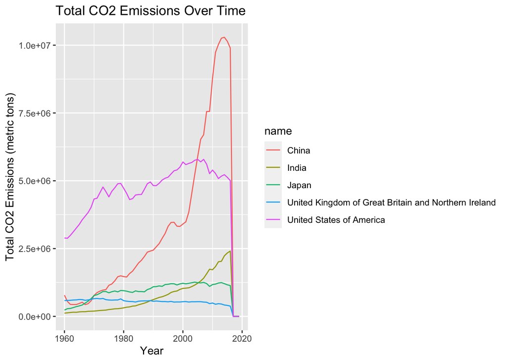

```r
few_countries <- c('United States of America', 'China', 'India', 'Japan', 'United Kingdom of Great Britain and Northern Ireland')

co2_select <- data %>%
  filter(name %in% few_countries) %>%
  group_by(name, time) %>%
  summarize(co2 = sum(co2, na.rm =TRUE), .groups = 'drop')

ggplot(co2_select, aes(x = time, y = co2, color = name)) + geom_line() +
  labs(title = "Total CO2 Emissions Over Time",
       x = "Year",
       y = "Total CO2 Emissions (metric tons)")
```

3. This figure shows that it is not China, but the United States of America that has the highest overall CO2 emissions per capita. Besides, rather than being a smooth and low emitter, the UK was in second place of my five chosen countries from 1960 to 1990, and was overtaken by Japan in the late 1990s. China and India have a relatively low emittion between 1960 to 2020, roughly lower than 2.5 tons per capita. While, China had a dramatic increase after 2000, and India had the lowest emissions of the five countries.

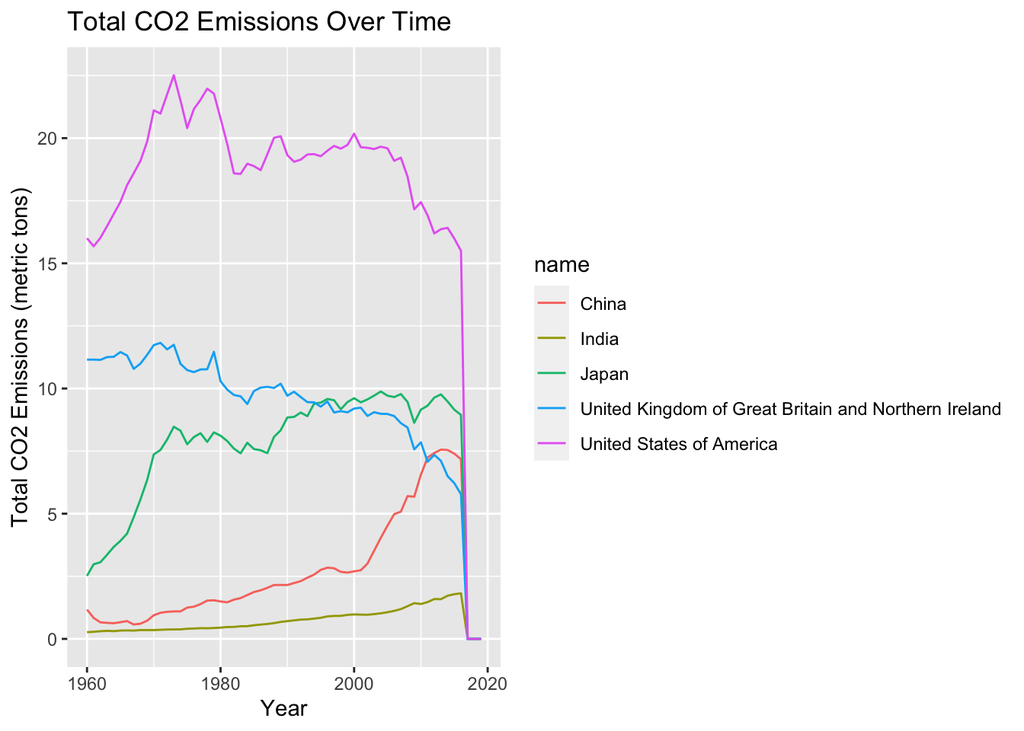

```r
few_countries <- c('United States of America', 'China', 'India', 'Japan', 'United Kingdom of Great Britain and Northern Ireland')

co2_pc_select <- data %>%
  filter(name %in% few_countries) %>%
  group_by(name, time) %>%
  summarize(co2_PC = sum(co2_PC, na.rm =TRUE), .groups = 'drop')

ggplot(co2_pc_select, aes(x = time, y = co2_PC, color = name)) + geom_line() +
  labs(title = "Total CO2 Emissions Over Time",
       x = "Year",
       y = "Total CO2 Emissions (metric tons)")
```

4. I found that Europe and Asia are the top regions average co2 emissions per capita, which are roughly 6.64 and 6.47 respectively. Besides, Africa is the region with the least average co2 emissions per capita.

```r
average_region <- data %>%
  filter(!is.na(region)) %>%
  filter(time == 2016) %>%
  group_by(region) %>%
  summarize(average_co2_pc = mean(co2_PC, na.rm = TRUE))

average_region
```

```
## # A tibble: 5 × 2
##   region   average_co2_pc
##   <chr>             <dbl>
## 1 Africa             1.20
## 2 Americas           4.80
## 3 Asia               6.47
## 4 Europe             6.64
## 5 Oceania            4.57
```

5. In the barplot, I found out that except in Americas, all other continents have increases in average co2 emissions per capita from 1960 to 2016.

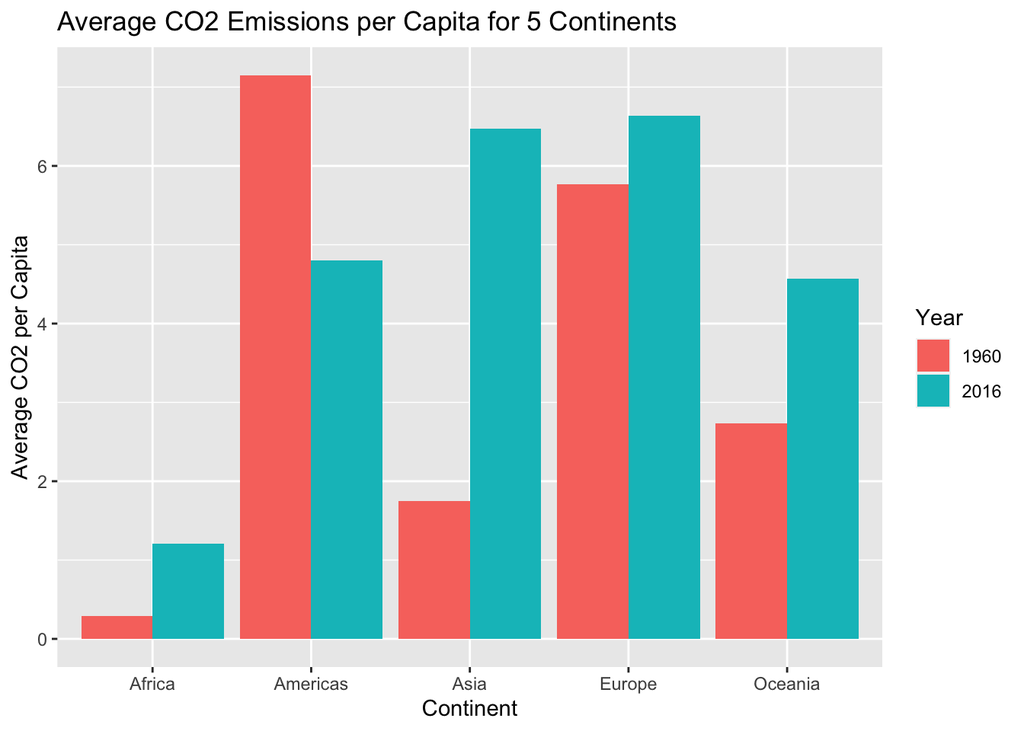

```r
compared_region <- data %>%
  filter(!is.na(region)) %>%
  filter(time == 1960 | time == 2016) %>%
  group_by(region, time) %>%
  summarize(average_co2_pc = mean(co2_PC, na.rm = TRUE), .groups = 'drop')

region_barplot <- ggplot(compared_region, aes(x = region, y = average_co2_pc, fill = as.factor(time))) +
  geom_bar(stat = "identity", position = position_dodge()) +
  labs(title = "Average CO2 Emissions per Capita for 5 Continents",
       x = "Continent", y = "Average CO2 per Capita") +
  scale_fill_discrete(name = "Year")

region_barplot
```

6. Because 2019 data is missing, I’ll take 2016 in this problem. The largest and smallest co2 emmiteers are showed in table.

```r
co2_per_2016 <- data %>%
  filter(!is.na(region), !is.na(co2_PC)) %>%
  filter(time == 2016) %>%
  group_by(region, name) %>%
  summarize(co2_for_country = sum(co2_PC, na.rm = TRUE), .groups = 'drop')

largest_three <- co2_per_2016 %>%
  group_by(region) %>%
  top_n(3, co2_for_country)

largest_three
```

```
## # A tibble: 15 × 3
## # Groups:   region [5]
##    region   name                     co2_for_country
##    <chr>    <chr>                              <dbl>
##  1 Africa   Libya                               7.79
##  2 Africa   Seychelles                          6.39
##  3 Africa   South Africa                        8.48
##  4 Americas Canada                             15.1
##  5 Americas Trinidad and Tobago                31.8
##  6 Americas United States of America           15.5
##  7 Asia     Bahrain                            22.2
##  8 Asia     Kuwait                             25.0
##  9 Asia     Qatar                              38.9
## 10 Europe   Faroe Islands                      13.1
## 11 Europe   Gibraltar                          18.8
## 12 Europe   Luxembourg                         15.4
## 13 Oceania  Australia                          15.5
## 14 Oceania  New Caledonia                      19.3
## 15 Oceania  Palau                              12.6
```

```r
smallest_three <- co2_per_2016 %>%
  group_by(region) %>%
  top_n(-3, co2_for_country)

smallest_three
```

```
## # A tibble: 15 × 3
## # Groups:   region [5]
##    region   name                              co2_for_country
##    <chr>    <chr>                                       <dbl>
##  1 Africa   Burundi                                    0.0472
##  2 Africa   Congo, Democratic Republic of the          0.0256
##  3 Africa   Somalia                                    0.0455
##  4 Americas Haiti                                      0.275
##  5 Americas Honduras                                   1.06
##  6 Americas Nicaragua                                  0.887
##  7 Asia     Afghanistan                                0.245
##  8 Asia     Nepal                                      0.334
##  9 Asia     Yemen                                      0.390
## 10 Europe   Albania                                    1.58
## 11 Europe   Liechtenstein                              1.36
## 12 Europe   Moldova, Republic of                       1.83
## 13 Oceania  Kiribati                                   0.587
## 14 Oceania  Solomon Islands                            0.272
## 15 Oceania  Vanuatu                                    0.527
```